# STAT 3032 - HW1

Saksham Goel

February 3, 2018

# Question 1 - Box Office Ticket Sales

### Introducing the Dataset

This section is dedicated to see and understand the data that was provided from the weekly reports about the box office ticket sales for plays in Broadway in New York. The data being observed is of the week of October 11- 17, 2004. The dataset contains data about the gross box office results for the current week October 11-17, 2004 and that of the previous week October 3-10, 2004.

The data table is as follows:

```r
ticketSales = read.csv("playbill.csv", header=T)
ticketSales[,]
```

| Production | CurrentWeek | LastWeek |
| --- | --- | --- |
| 42nd Street | 684966 | 695437 |
| Avenue Q | 502367 | 498969 |
| Beauty and Beast | 594474 | 598576 |
| Bombay Dreams | 529298 | 528994 |
| Chicago | 570254 | 562964 |
| Dracula | 319959 | 282778 |
| Fiddler on the Roof | 579126 | 583177 |
| Forever Tango | 134042 | 152833 |
| Golda's Balcony | 105853 | 105698 |
| Hairspray | 822775 | 836959 |

[output cut: 8 more lines]

### Visualizing the Dataset

The dataset can be visalized through a scatterplot in the figure below:

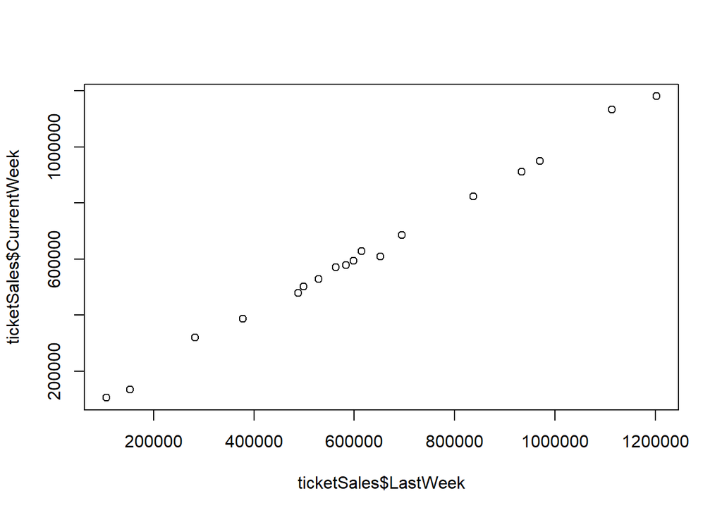

```r
plot(x = ticketSales$LastWeek, y = ticketSales$CurrentWeek)
```

### Fitting a linear model

The linear trend in the scatterplot seems strong, which means that a linear regression model is appropriate. The linear model that we are trying to fit is of the form:

here, X = Gross Box Office results for Previous Week Y = Gross Box Office results for Current Week.

Through this linear model we are trying to predict the value of actual gross box office reults of current week (Y) using the gross box office results of the previous week (X). The following snippet of the R-Code fits a linear model on the data, prints out the values of the intercept and slope and also provides a summary of the fitted model.

```r
mod = lm( ticketSales$CurrentWeek ~ ticketSales$LastWeek )
mod
```

```
##
## Call:
## lm(formula = ticketSales$CurrentWeek ~ ticketSales$LastWeek)
##
## Coefficients:
##          (Intercept)  ticketSales$LastWeek
##            6804.8860                0.9821
```

The summary of the model is as follows:

```r
summary(mod)
```

```
##
## Call:
## lm(formula = ticketSales$CurrentWeek ~ ticketSales$LastWeek)
##
## Residuals:
##    Min     1Q Median     3Q    Max
## -36926  -7525  -2581   7782  35443
##
## Coefficients:
##                       Estimate Std. Error t value Pr(>|t|)
## (Intercept)          6.805e+03  9.929e+03   0.685    0.503
## ticketSales$LastWeek 9.821e-01  1.443e-02  68.071   <2e-16 ***
## ---
## Signif. codes:  0 '***' 0.001 '**' 0.01 '*' 0.05 '.' 0.1 ' ' 1
##
## Residual standard error: 18010 on 16 degrees of freedom
## Multiple R-squared:  0.9966, Adjusted R-squared:  0.9963
## F-statistic:  4634 on 1 and 16 DF,  p-value: < 2.2e-16
```

The summary provides us with a lot of useful values that we will use in the upcoming sections to calculate the Confidence Intervals, Prediction Intervals and perform Hypothesis Testing. Some of the values are as follows:

Combining all the information from the previous sections the final fitted model looks as follows:

### Finding a 95% Confidence Interval for $\beta_1$

A $100(1-\alpha)\%$ confidence interval for $\hat{\beta_1}$ is given by the following formula:

The following snippet of code is used to find the 95% confidence interval for $\hat{\beta_1}$:

```r
bet1_hat = 0.9821 #found using the linear model
x_col = ticketSales$LastWeek
y_col = ticketSales$CurrentWeek
x_bar = mean(x_col)
#x_bar = 622186.6
y_bar = mean(y_col)
#y_bar = 617842.8
sxx = sum((x_col-x_bar)^2)
#sxx = 1.557916 * 10^12
sxy = sum((x_col-x_bar)*(y_col-y_bar))
#sxy = 1.53 * 10^12
#sxy/sxx = 0.9821
s = 18010 #found through the summary of the linear model
t_mult = 2.120 # found using the T Table, equal to t0.25 for 16 degrees of freedom
beta1CIlower = bet1_hat - (t_mult*(s/sqrt(sxx)))
beta1CIupper = bet1_hat + (t_mult*(s/sqrt(sxx)))
```

Yes we can say that $1$ is a reasonable value for $\beta_1$ because $1$ lies in the $95\%$ Confidence Interval of $\beta_1$

### Hypothesis Testing for $\beta_0$

We need to run a Hypothesis Test for $\beta_0$ given by:

The hypothesis test for $\beta_0$ is given by the following formula:

To find the p-value we then use the t-statistic we got from the previous formula and find the probability as follows:

The following snippet of code is used to perform the Hypothesis Test for $\beta_0$:

```r
bet0_hat = 6804.8860 #this value was found using the linear model through r in the previous section
x_col = ticketSales$LastWeek
x_bar = mean(x_col)
#x_bar = 622186.6
sxx = sum((x_col-x_bar)^2)
#sxx = 1.557916 * 10^12
s = 18010 #found through the summary of the linear model
t_mult = 2.120 # found using the T Table, equal to t0.25 for 16 degrees of freedom
n = length(x_col)
beta0test = ((bet0_hat - 10000)/(s * sqrt((1/n) + ((x_bar^2)/sxx))))
#beta0test =  -0.3217422
p_val = 2*pt(-abs(beta0test), df = n-2)
#p_val = 0.7518132
```

After performing the Hypothesis test for $\beta_0$ we find that the $p-value = 0.7518132$ which is greater than $0.05$, hence we cannot reject the null hypothesis.

### Point Estimate for new Y

Through the previous sections we know that:

So to find the point estimate of Y using the fitted model we get:

```r
X = 400000 #X value for which we need to find the estimated value
Y = 6804.8860 + (0.9821 * X)
#Y = 399644.9
```

Through this above snippet of code we get the point estimate of $Y$ at $X = 400,000$ as $Y = 399644.9$.

### Prediction Interval for new Y

There is no use of a Linear Model if we cannot predict new values of the parameter Y through X. In this section we will construct a prediction interval of the Y value using the formulas provided in the book. The prediction interval of Y is given by the formula as follows:

The following snippet of code helps us to find the upper and lower limits of the Prediction Interval for the new Y as follows:

```r
#fitted model =
# Y = 6804.8860 + 0.9821 * X
x_curr = 400000 #the value at which we need to find the prediction interval
y_hat = 6804.8860 + (0.9821 * x_curr)
#y_hat = 399644.9.
mse = mean(mod$residuals^2)  # mean((ticketSales$CurrentWeek - predict(mod))^2)
#mse = 288241878
x_col = ticketSales$LastWeek
x_bar = mean(x_col)
#x_bar = 622186.6
sxx = sum((x_col-x_bar)^2)
#sxx = 1.557916 * 10^12
s = 18010 #found through the summary of the linear model
t_mult = 2.120 # found using the T Table, equal to t0.25 for 16 degrees of freedom
n = length(x_col)
yPILower = y_hat - (t_mult * sqrt(mse) * sqrt(1 + (1/n) + (((x_curr - x_bar)^2)/sxx) ))
yPIUpper = y_hat + (t_mult * sqrt(mse) * sqrt(1 + (1/n) + (((x_curr - x_bar)^2)/sxx) ))
#yPILower = 362115
#yPIUpper = 437174.8
```

Because the prediction interval does not contain the value $450,000$ in it, we cannot use that value as a prediction.

### Comment:

I think that is a statement that could be used frequently to describe the sales record for the broadway show, because the linear model also seems to follow a trend as seen. Other than that all the results from the previous computations seems to provide a good enough evidence to support this claim.

# Question 2 - Processing Time of Invoices

### Introducing the Dataset

This section is dedicated to see and understand the data that was provided from a large company about the number of invoices processed and the total processing time for those invoices. The data being observed is of a whole month. The data table is as follows:

```r
invoiceTime = read.table("invoices.txt", header = T)
invoiceTime[,]
```

| Day | Invoices | Time |
| --- | --- | --- |
| 1 | 149 | 2.1 |
| 2 | 60 | 1.8 |
| 3 | 188 | 2.3 |
| 4 | 23 | 0.8 |
| 5 | 201 | 2.7 |
| 6 | 58 | 1.0 |
| 7 | 77 | 1.7 |
| 8 | 222 | 3.1 |
| 9 | 181 | 2.8 |
| 10 | 30 | 1.0 |

[output cut: 20 more lines]

### Visualizing the Dataset

The dataset can be visalized through a scatterplot in the figure below:

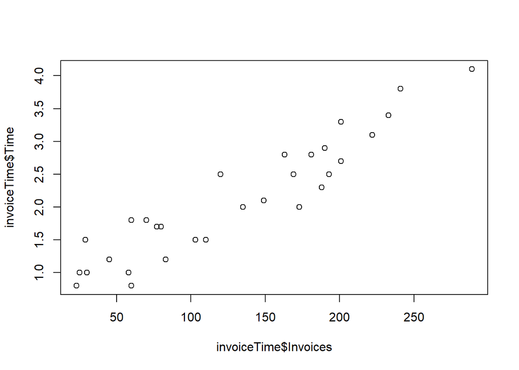

```r
plot(x = invoiceTime$Invoices, y = invoiceTime$Time)
```

### Fitting a linear model

The linear trend in the scatterplot seems strong, which means that a linear regression model is appropriate. The linear model that we are trying to fit is of the form:

here, X = Number of Invoices Y = Total Time required to process those Invoices

Through this linear model we are trying to predict the value of total time required to process invoices (Y) using the number of invoices (X). The following snippet of the R-Code fits a linear model on the data, prints out the values of the intercept and slope and also provides a summary of the fitted model.

```r
mod = lm(invoiceTime$Time ~ invoiceTime$Invoices )
mod
```

```
##
## Call:
## lm(formula = invoiceTime$Time ~ invoiceTime$Invoices)
##
## Coefficients:
##          (Intercept)  invoiceTime$Invoices
##              0.64171               0.01129
```

The summary of the model is as follows:

```r
summary(mod)
```

```
##
## Call:
## lm(formula = invoiceTime$Time ~ invoiceTime$Invoices)
##
## Residuals:
##      Min       1Q   Median       3Q      Max
## -0.59516 -0.27851  0.03485  0.19346  0.53083
##
## Coefficients:
##                       Estimate Std. Error t value Pr(>|t|)
## (Intercept)          0.6417099  0.1222707   5.248 1.41e-05 ***
## invoiceTime$Invoices 0.0112916  0.0008184  13.797 5.17e-14 ***
## ---
## Signif. codes:  0 '***' 0.001 '**' 0.01 '*' 0.05 '.' 0.1 ' ' 1
##
## Residual standard error: 0.3298 on 28 degrees of freedom
## Multiple R-squared:  0.8718, Adjusted R-squared:  0.8672
## F-statistic: 190.4 on 1 and 28 DF,  p-value: 5.175e-14
```

The summary provides us with a lot of useful values that we will use in the upcoming sections to calculate the Confidence Intervals, Prediction Intervals and perform Hypothesis Testing. Some of the values are as follows:

Combining all the information from the previous sections the final fitted model looks as follows:

### Finding a 95% Confidence Inrerval $\beta_0$

A $100(1-\alpha)\%$ confidence interval for $\hat{\beta_0}$ is given by the following formula:

The following snippet of code is used to find the $95\%$ confidence interval for $\hat{\beta_0}$:

```r
bet0_hat = 0.6417099 #using the linear model fit from prevous section
x_col = invoiceTime$Invoices
x_bar = mean(x_col)
#x_bar = 130.0333
sxx = sum((x_col-x_bar)^2)
#sxx = 162367
n = length(x_col)
#n = 30
s = 0.3298 #found through the summary of the linear model
t_mult = 2.048 #found using the T Table, equal to t0.25 for 28 degrees of freedom
beta0CIlower = bet0_hat - ( t_mult * s * sqrt( (1/n) + ((x_bar^2)/(sxx)) ) )
beta0CIupper = bet0_hat + ( t_mult * s * sqrt( (1/n) + ((x_bar^2)/(sxx)) ) )
#beta0CIlower = 0.3912792
#beta0CIupper = 0.8921406
```

### Hypothesis Testing for $\beta_1$

The following snippet of code is used to perform the Hypothesis Test for $\beta_1$:

```r
bet1_hat = 0.0112916 #found using the linear model in the previous sections
x_col = invoiceTime$Invoices
y_col = invoiceTime$Time
x_bar = mean(x_col)
#x_bar = 130.0333
y_bar = mean(y_col)
#y_bar = 2.11
sxx = sum((x_col-x_bar)^2)
#sxx = 162367
sxy = sum((x_col-x_bar)*(y_col-y_bar))
#sxy = 1833.39
#sxy/sxx = 0.0112916
n = length(x_col)
s = 0.3298 #found through the summary of the linear model
t_mult = 2.048 #found using the T Table, equal to t0.25 for 28 degrees of freedom
beta1test = ( ( bet1_hat - 0.01 )/( s/sqrt( sxx ) ) )
#beta1test = 1.57807
p_val = 2*pt(-abs(beta1test), df = n-2)
#p_val = 0.1257819
```

After performing the Hypothesis test for $\beta_1$ we find that the $p-value = 0.1257819$ which is greater than $0.05$, hence we cannot reject the null hypothesis.

### Point Estimate for new Y

Through the previous sections we know that:

So to find the point estimate of Y using the fitted model we get:

```r
X = 130 #X value for which we need to find the estimated value
Y = 0.6417099 + 0.0112916 * X
#Y = 2.109618
```

Through this above snippet of code we get the point estimate of $Y$ at $X = 130$ as $Y = 2.109618$ which is roughly equal to $127 mins$.

### Prediction Interval for new Y

There is no use of a Linear Model if we cannot predict new values of the parameter Y through X. In this section we will construct a prediction interval of the Y value using the formulas provided in the book. The prediction interval of Y is given by the formula as follows:

The following snippet of code helps us to find the upper and lower limits of the Prediction Interval for the new Y as follows:

```r
#fitted model =
# Y = 0.6417099 + 0.0112916 * X
x_curr = 130 #the value at which we need to find the prediction interval
y_hat = 0.6417099 + (0.0112916 * x_curr)
#y_hat = 2.109618
mse = mean(mod$residuals^2) # mean((invoiceTime$Times - predict(mod))^2)
#mse = 0.1015004
x_col = invoiceTime$Invoices
x_bar = mean(x_col)
#x_bar = 130.0333
sxx = sum((x_col-x_bar)^2)
#sxx = 162367
n = length(x_col)
s = 0.3298 #found through the summary of the linear model
t_mult = 2.048 #found using the T Table, equal to t0.25 for 28 degrees of freedom
yPILower = y_hat - (t_mult * sqrt(mse) * sqrt(1 + (1/n) + (((x_curr - x_bar)^2)/sxx) ))
yPIUpper = y_hat + (t_mult * sqrt(mse) * sqrt(1 + (1/n) + (((x_curr - x_bar)^2)/sxx) ))
#yPILower = 1.446357
#yPIUpper = 2.772878
```